# Forecasting Credit Default

Thu Nguyen

9/30/2020

**Prework: Load packages.** #Load needed packages

```r
library(kernlab)
library(xgboost)
library(zoo)
library(readr)
library(scales)
library(plyr)
library(gbm)
```

```r
library(Metrics)
library(parsnip)
library(parttree)
library(rpart)
library(rpart.plot)
library(devtools)
library(ggplot2)
library(gridExtra)
library(repr)
library(dplyr)
library(caret)
library(randomForest)
library(MLmetrics)
library(tidyverse)
library(chron)
library(ROCR)
library(pROC)
library(quantmod)
library(stringr)
library(lattice)
library(e1071)
library(cluster)
library(data.table)
library(randomForest)
library(broom)
library(mapproj)
library(MASS)
library(lubridate)
```

#Loading Data

```r
loans <- read.csv("loans.csv")
```

### Part 1 (Exploring and Observing the data to understand it well)

1/ Cleaning the dataset and choosing importance variables for my model later.

#Creating Meta Data_The meta data will give us more detail about the data such as which variables are present in loan data set and what is their type. We will need the meta data at a later stage so we assign it to a variable

```r
meta_loans <- funModeling::df_status(loans, print_results = FALSE)
knitr::kable(meta_loans)
```

| variable | q_zeros | p_zeros | q_na | p_na | q_inf | p_inf | type | unique |
| --- | --- | --- | --- | --- | --- | --- | --- | --- |
| id | 0 | 0.00 | 0 | 0.00 | 0 | 0 | integer | 1010497 |
| member_id | 0 | 0.00 | 1010497 | 100.00 | 0 | 0 | logical | 0 |
| loan_amnt | 0 | 0.00 | 0 | 0.00 | 0 | 0 | integer | 1561 |
| funded_amnt | 0 | 0.00 | 0 | 0.00 | 0 | 0 | integer | 1561 |
| funded_amnt_inv | 0 | 0.00 | 0 | 0.00 | 0 | 0 | numeric | 1575 |
| term | 0 | 0.00 | 0 | 0.00 | 0 | 0 | character | 2 |
| int_rate | 0 | 0.00 | 0 | 0.00 | 0 | 0 | character | 191 |
| installment | 0 | 0.00 | 0 | 0.00 | 0 | 0 | numeric | 49756 |
| grade | 0 | 0.00 | 0 | 0.00 | 0 | 0 | character | 7 |
| sub_grade | 0 | 0.00 | 0 | 0.00 | 0 | 0 | character | 35 |
| emp_title | 0 | 0.00 | 10 | 0.00 | 0 | 0 | character | 218686 |
| emp_length | 0 | 0.00 | 0 | 0.00 | 0 | 0 | character | 12 |
| home_ownership | 0 | 0.00 | 0 | 0.00 | 0 | 0 | character | 5 |
| annual_inc | 2190 | 0.22 | 0 | 0.00 | 0 | 0 | numeric | 50595 |
| verification_status | 0 | 0.00 | 0 | 0.00 | 0 | 0 | character | 3 |
| issue_d | 0 | 0.00 | 0 | 0.00 | 0 | 0 | character | 24 |
| loan_status | 0 | 0.00 | 0 | 0.00 | 0 | 0 | character | 8 |
| pymnt_plan | 0 | 0.00 | 0 | 0.00 | 0 | 0 | character | 1 |
| url | 0 | 0.00 | 0 | 0.00 | 0 | 0 | character | 1010497 |
| desc | 0 | 0.00 | 1010497 | 100.00 | 0 | 0 | logical | 0 |
| purpose | 0 | 0.00 | 0 | 0.00 | 0 | 0 | character | 12 |
| title | 0 | 0.00 | 0 | 0.00 | 0 | 0 | character | 12 |
| zip_code | 0 | 0.00 | 0 | 0.00 | 0 | 0 | character | 911 |
| addr_state | 0 | 0.00 | 0 | 0.00 | 0 | 0 | character | 50 |
| dti | 1163 | 0.12 | 2207 | 0.22 | 0 | 0 | numeric | 11930 |
| delinq_2yrs | 862263 | 85.33 | 0 | 0.00 | 0 | 0 | integer | 28 |
| earliest_cr_line | 0 | 0.00 | 0 | 0.00 | 0 | 0 | character | 1581 |
| fico_range_low | 0 | 0.00 | 0 | 0.00 | 0 | 0 | integer | 38 |
| fico_range_high | 0 | 0.00 | 0 | 0.00 | 0 | 0 | integer | 38 |
| inq_last_6mths | 664609 | 65.77 | 0 | 0.00 | 0 | 0 | integer | 6 |

[output cut: 121 more lines]

```r
chr_to_num_vars <- c("annual_inc_joint", "mths_since_last_major_derog", "open_acc_6m", "open_il_12m", "open_il_24m", "mths_since_rcnt_il", "total_bal_il", "il_util", "open_rv_12m", "open_rv_24m", "max_bal_bc", "all_util", "total_rev_hi_lim", "total_cu_tl", "inq_last_12m", "dti_joint", "inq_fi", "tot_cur_bal", "tot_coll_amt")

loans <- loans %>% mutate_at(.funs = funs(as.numeric), .vars = chr_to_num_vars)
```

#Checking date variables

```r
chr_to_date_vars <- c("issue_d", "last_pymnt_d", "last_credit_pull_d", "next_pymnt_d", "earliest_cr_line", "next_pymnt_d")

loans %>% select_(.dots = chr_to_date_vars) %>% str()
```

```
## 'data.frame':    1010497 obs. of  5 variables:
##  $ issue_d           : chr  "20-Mar" "20-Mar" "20-Mar" "20-Mar" ...
##  $ last_pymnt_d      : chr  "20-Aug" "20-Aug" "20-Aug" "20-Aug" ...
##  $ last_credit_pull_d: chr  "20-Aug" "20-Aug" "20-Aug" "20-Aug" ...
##  $ next_pymnt_d      : chr  "20-Sep" "20-Sep" "20-Sep" "" ...
##  $ earliest_cr_line  : chr  "15-May" "9-Jan" "6-Aug" "6-Aug" ...
```

```r
for (i in chr_to_date_vars){
  print(head(unique(loans[, i])))
  }
```

```
## [1] "20-Mar" "20-Feb" "20-Jan" "Dec-19" "Nov-19" "Oct-19"
## [1] "20-Aug" "20-Jul" "20-May" "20-Apr" "20-Jun" ""
## [1] "20-Aug" "20-Mar" "20-Jul" "20-Jun" "20-May" "20-Apr"
## [1] "20-Sep" ""       "20-Aug" "20-Oct" "20-Apr" "20-Nov"
## [1] "15-May" "9-Jan"  "6-Aug"  "10-Oct" "Aug-98" "Nov-99"
## [1] "20-Sep" ""       "20-Aug" "20-Oct" "20-Apr" "20-Nov"
```

```r
detach(package:MASS)
meta_loans %>% select(variable, q_na) %>% filter(variable %in% chr_to_date_vars)
```

```
##             variable q_na
## 1            issue_d    0
## 2   earliest_cr_line    0
## 3       last_pymnt_d    0
## 4       next_pymnt_d    0
## 5 last_credit_pull_d    0
```

#Convert Date to correct data type

```r
convert_date <- function(x){
  as.Date(paste0("01-", x), format = "%d-%b-%Y")
  }

loans <-
  loans %>%
  mutate_at(.funs = funs(convert_date), .vars = chr_to_date_vars)

num_vars <-
  loans %>%
  sapply(is.numeric) %>%
  which() %>%
  names()

meta_loans %>%
  select(variable, p_zeros, p_na, unique) %>%
  filter_(~ variable %in% num_vars) %>%
  knitr::kable()
```

| variable | p_zeros | p_na | unique |
| --- | --- | --- | --- |
| id | 0.00 | 0.00 | 1010497 |
| loan_amnt | 0.00 | 0.00 | 1561 |
| funded_amnt | 0.00 | 0.00 | 1561 |
| funded_amnt_inv | 0.00 | 0.00 | 1575 |
| installment | 0.00 | 0.00 | 49756 |
| annual_inc | 0.22 | 0.00 | 50595 |
| dti | 0.12 | 0.22 | 11930 |
| delinq_2yrs | 85.33 | 0.00 | 28 |
| fico_range_low | 0.00 | 0.00 | 38 |
| fico_range_high | 0.00 | 0.00 | 38 |
| inq_last_6mths | 65.77 | 0.00 | 6 |
| mths_since_last_delinq | 0.00 | 56.34 | 172 |
| mths_since_last_record | 0.00 | 88.87 | 128 |
| open_acc | 0.01 | 0.00 | 87 |
| pub_rec | 88.87 | 0.00 | 11 |
| revol_bal | 0.85 | 0.00 | 83981 |
| total_acc | 0.00 | 0.00 | 140 |
| out_prncp | 27.71 | 0.00 | 408569 |
| out_prncp_inv | 27.71 | 0.00 | 412870 |
| total_pymnt | 0.09 | 0.00 | 543386 |
| total_pymnt_inv | 0.09 | 0.00 | 521727 |
| total_rec_prncp | 0.19 | 0.00 | 386906 |
| total_rec_int | 0.17 | 0.00 | 392064 |
| total_rec_late_fee | 97.81 | 0.00 | 5223 |
| recoveries | 96.78 | 0.00 | 26802 |
| collection_recovery_fee | 96.79 | 0.00 | 26952 |
| last_pymnt_amnt | 2.46 | 0.00 | 249392 |
| last_fico_range_high | 0.00 | 0.00 | 72 |
| last_fico_range_low | 0.78 | 0.00 | 71 |
| collections_12_mths_ex_med | 98.43 | 0.00 | 10 |

[output cut: 82 more lines]

```r
na_to_zero_vars <- c("mths_since_last_delinq", "mths_since_last_record", "mths_since_last_major_derog")

loans <- loans %>% mutate_at(.vars = na_to_zero_vars, .funs = funs(replace(., is.na(.), 0)))

meta_loans <- funModeling::df_status(loans, print_results = FALSE)

meta_loans <- meta_loans %>% mutate(uniq_rat = unique / nrow(loans))
```

2/ Defining default loans

#Checking unique potential variables that may indicate a default or delay in payments: loan_status, delinq_2yrs, mths_since_last_delinq

```r
default_vars <- c("loan_status", "delinq_2yrs", "mths_since_last_delinq")
purrr::map(.x = loans[, default_vars], .f = base::unique)
```

```
## $loan_status
## [1] "Current"            "Fully Paid"         "In Grace Period"
## [4] "Issued"             "Charged Off"        "Late (31-120 days)"
## [7] "Late (16-30 days)"  "Default"
##
## $delinq_2yrs
##  [1]  0  4  1  2  3  7  9 17  6  5 11  8 10 15 19 13 14 12 16 18 23 26 22 21 25
## [26] 24 58 35
##
## $mths_since_last_delinq
##   [1]   0  47   3  26  56   8  49  73  51  37  58   6  35   7  42  68  36  64
##  [19]  39  21  28  13  66  70  19  53   5  57  72  79  32  31  52  69  43  11
##  [37]  45  25  60   4   9  34  29  40  17  16  55  14  15  81  44  12  61  48
##  [55]  59  23  27  24  33  20  50  67  63  30  77  54  71  38  82  22  78  18
##  [73]   2  46 128  10  62  74  65  75  76  80  41   1 138  99 115  90 103 127
##  [91] 144 129 135 120 212  91 119  89  83  87 116 112 126 107  94  93  86  84
## [109] 105 109  96 122 136  92 133  88 124  95 102  97 131 125 118 130 172 111
## [127]  98 137 106 139 104 108 110 101 134 145 161  85 117 160 100 123 113 121
## [145] 157 114 149 132 142 164 154 151 163 143 168 169 165 159 167 162 192 202
## [163] 176 153 150 146 141 179 147 171 152 148
```

#Defining default loans as follow

```r
defaulted <- c("Default", "Does not meet the credit policy. Status:Charged Off", "In Grace Period", "Late (16-30 days)", "Late (31-120 days)")

loans <- loans %>% mutate(default = ifelse(!(loan_status %in% defaulted), FALSE, TRUE))
```

#Compute the frequency of actual defaults in the training set. It is around 0.02286

```r
detach(package:plyr)

loans %>% summarise(default_freq = sum(default / n()))
```

```
##   default_freq
## 1   0.02286894
```

```r
table(loans$default) / nrow(loans)
```

```
##
##      FALSE       TRUE
## 0.97713106 0.02286894
```

#Selecting variables that fit for my modeling. I will remove variables that are key variable, have high NA ratio and have high amount of unique values

```r
loans2 <- loans %>% select(loan_amnt, funded_amnt, funded_amnt_inv, loan_status, int_rate, grade, emp_length, home_ownership, annual_inc, term, purpose, total_acc, last_fico_range_high, last_fico_range_low, default)
```

#Creating train & test dataset

```r
set.seed(6438)

train_index <- caret::createDataPartition(y = loans2$default, times = 1, p = .8, list = FALSE)
train <- loans2[train_index, ]
test <- loans2[-train_index, ]

rm(loans2)
```

###Part 2 (Analyzing relationship between variables which i think Lending Club based on to give approval decision)

2.1/ Explore income and loan amount

#Assign continous variables to a character vector and reshape data for plotting of distributions

```r
library(scales)
income_vars <- c("annual_inc")
loan_amount_vars <- c("loan_amnt", "funded_amnt", "funded_amnt_inv")
```

#Reshape and plot the original data for specified variables in a tidyr-dplyr-ggplot pipe

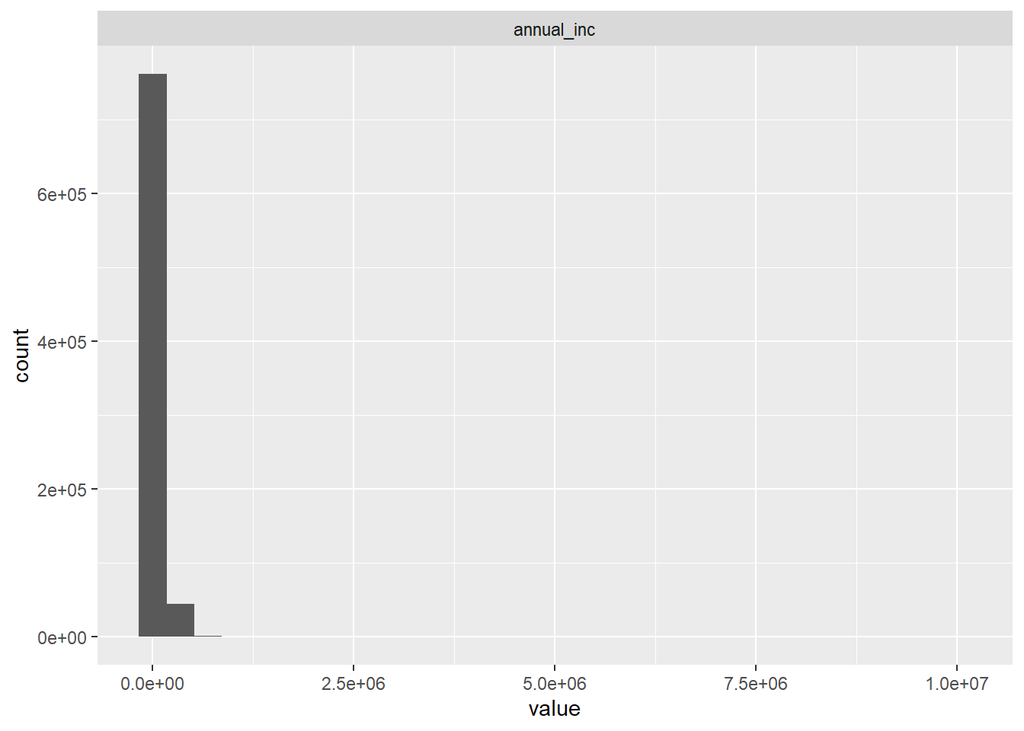

```r
train %>% select_(.dots = income_vars) %>% gather_("variable", "value", gather_cols = income_vars) %>% ggplot(aes(x = value)) + facet_wrap(~ variable, scales = "free_x", ncol = 3) + geom_histogram()
```

#Loan_amnt Vs Funded_amnt Vs Funded_amnt_inv

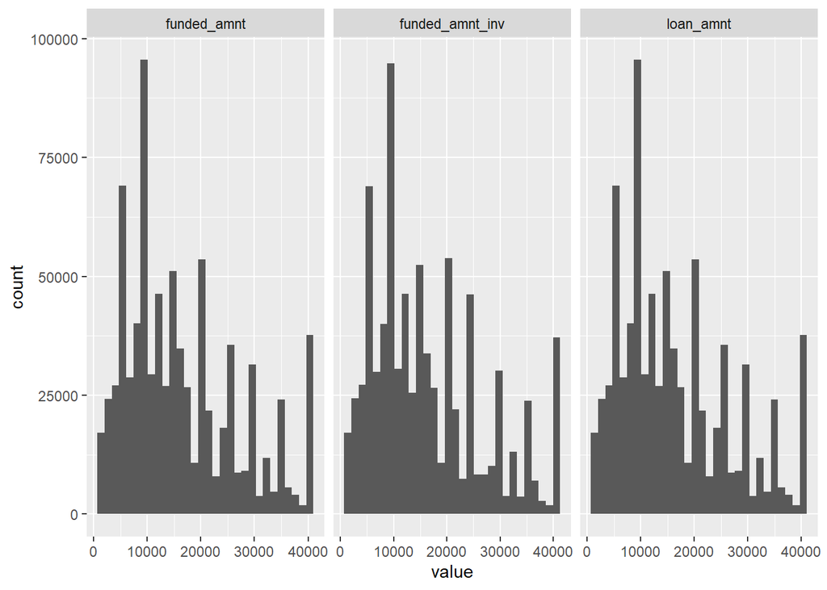

```r
train %>%
  select_(.dots = loan_amount_vars) %>%
  gather_("variable", "value", gather_cols = loan_amount_vars) %>%
  ggplot(aes(x = value)) +
  facet_wrap(~ variable, scales = "free_x", ncol = 3) +
  geom_histogram()
```

The loan amount distributions seems similar in shape suggesting not too much divergence between the loan amount applied for, the amount committed and the amount invested. It means that most likely qualified borrowers are going to get the loan they had applied for.

#Combine my selection with the meta information gathered in an earlier stage to see the information power and uniqueness

```r
categorical_vars <- c("term", "grade", "sub_grade", "emp_title", "home_ownership", "verification_status", "loan_status", "purpose", "zip_code", "addr_state", "application_type", "policy_code")

meta_loans %>% select(variable, p_zeros, p_na, type, unique) %>% filter_(~ variable %in% categorical_vars) %>% knitr::kable()
```

[output not shown]

2.2/Relationship between Default rate, Grade, Interest rate, Loan Amount and Income.

```
a/ Loan Amount Vs. Grades
```

#Investigate the distribution of loan amount over the different grades

```r
give_count <-
  stat_summary(fun.data = function(x) return(c(y = median(x)*1.06,
                                               label = length(x))),
               geom = "text")

give_mean <-
  stat_summary(fun.y = mean, colour = "darkgreen", geom = "point",
               shape = 18, size = 3, show.legend = FALSE)
```

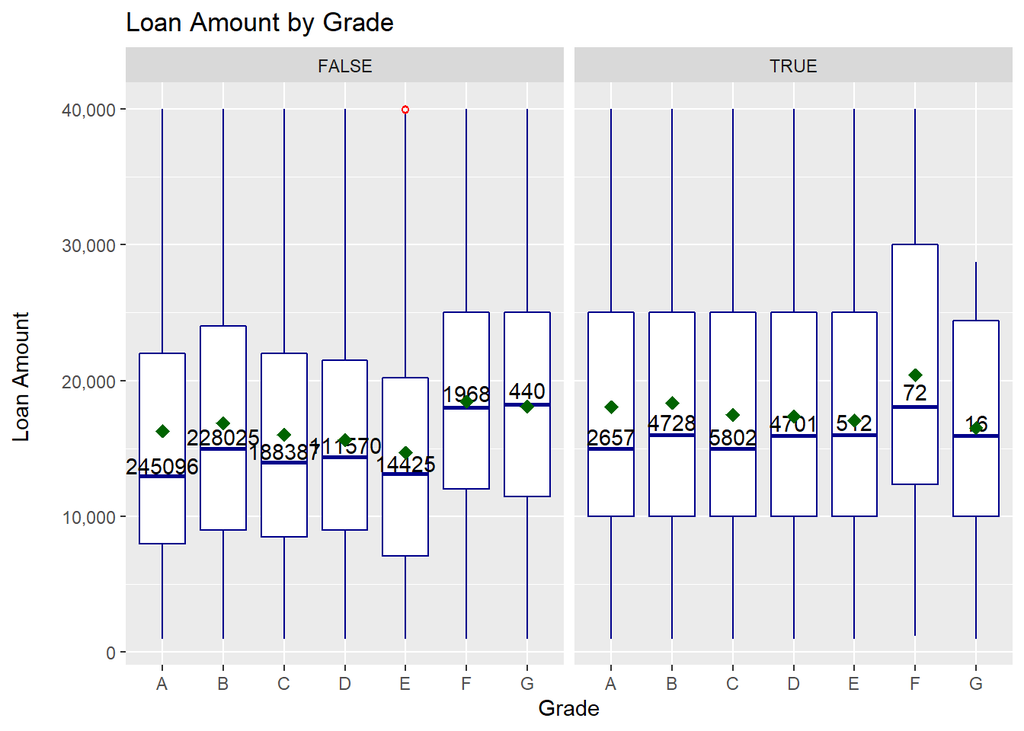

```r
train %>%
  ggplot(aes(grade, loan_amnt)) +
  geom_boxplot(fill = "white", colour = "darkblue",
               outlier.colour = "red", outlier.shape = 1) +
  give_count +
  give_mean +
  scale_y_continuous(labels = comma) +
  facet_wrap(~ default) +
  labs(title="Loan Amount by Grade", x = "Grade", y = "Loan Amount \n")
```

We can derive a few points from the plot: there is not a lot of difference between default and non-default, lower quality loans tend to have a higher loan amount, there are no outliers except for grade E and the loan amount spread (IQR) seems to be slightly higher for lower quality loans

```
b/ Default rate Vs Grade
```

#Checking number of default loans in each grade level

```r
g1 = train %>% filter(default == "TRUE") %>% group_by(grade) %>% summarise(default_count = n())

g1
```

```
## # A tibble: 7 x 2
##   grade default_count
##   <chr>         <int>
## 1 A              2657
## 2 B              4728
## 3 C              5802
## 4 D              4701
## 5 E               512
## 6 F                72
## 7 G                16
```

#Creating default rate for each grade

```r
g2 = train %>% group_by(grade) %>% summarise(count = n())
g3 <- g2 %>% left_join(g1) %>% mutate(default_rate = 100*default_count/count) %>% select(grade,count,default_count,default_rate)
g3
```

```
## # A tibble: 7 x 4
##   grade  count default_count default_rate
##   <chr>  <int>         <int>        <dbl>
## 1 A     247753          2657         1.07
## 2 B     232753          4728         2.03
## 3 C     194189          5802         2.99
## 4 D     116271          4701         4.04
## 5 E      14937           512         3.43
## 6 F       2040            72         3.53
## 7 G        456            16         3.51
```

#Plot Default rate Vs Grade

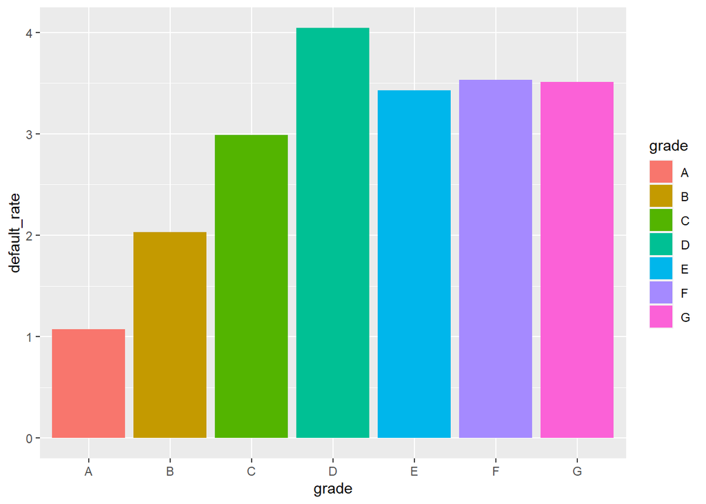

```r
ggplot(g3, aes(x=grade, y=default_rate, fill=grade)) + geom_bar(stat="identity")
```

As we would expect, riskier loans have higher default rates, except grade D has higher default rate than E, F and G. It is because the number of loans that got funded by the Lending Club for grade E, F and G are much smaller than other grades.

```
c/ Loan Amount Vs Income
```

#Reshape the data to have both loan values plotted against loan amount

```r
funded_amnt <- train %>% transmute(loan_amnt = loan_amnt, value = funded_amnt, variable = "funded_amnt")

funded_amnt_inv <- train %>% transmute(loan_amnt = loan_amnt, value = funded_amnt_inv, variable = "funded_amnt_inv")

plot_data <- rbind(funded_amnt, funded_amnt_inv)

rm(list = ls()[grep("^funded", ls())])
```

#Plot loan_amnt, funded_amnt, funded_amnt_inv

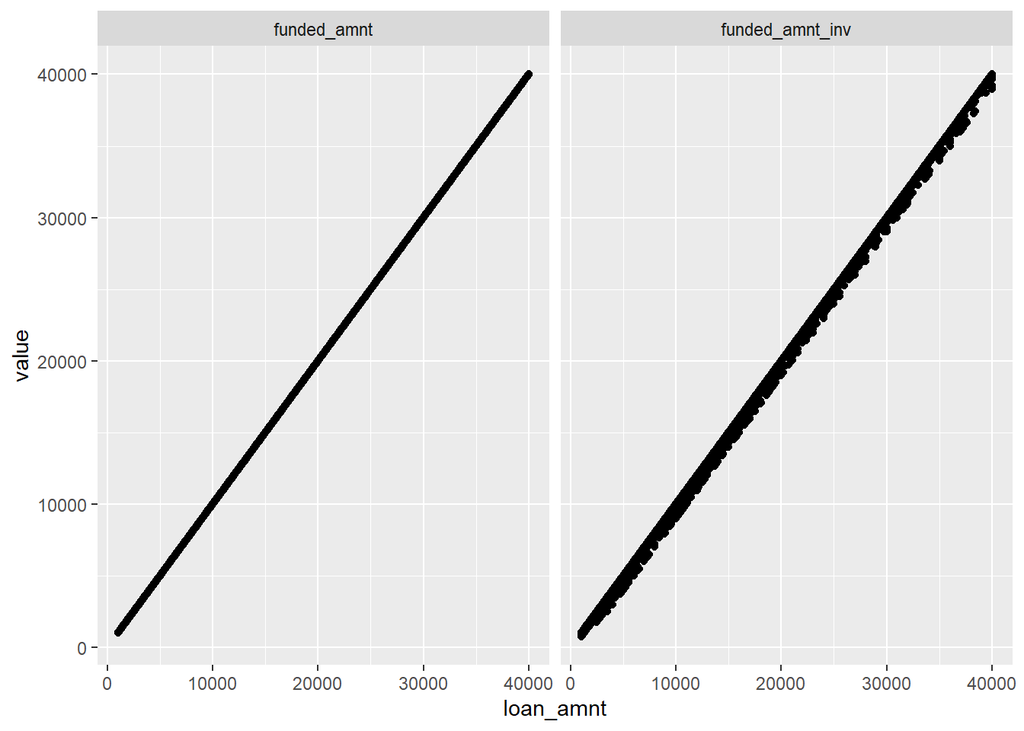

```r
plot_data %>% ggplot(aes(x = loan_amnt, y = value)) + facet_wrap(~ variable, scales = "free_x", ncol = 3) + geom_point()
```

#Annual income vs. loan amount only

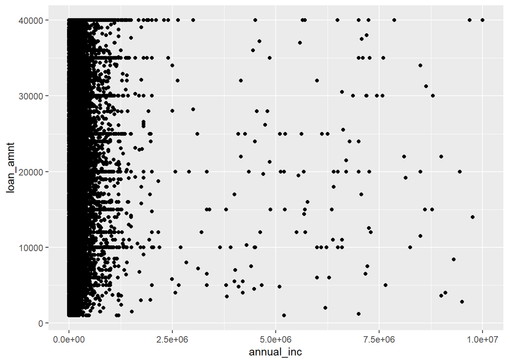

```r
train %>% ggplot(aes(x = annual_inc, y = loan_amnt)) + geom_point()
```

We can derive a few points from the plot: there is no immediatly discernible relationship, there are quite a few income outliers with questionable values (e.g. why would a person with annual income of 1 millione request a loan amount of 40,000)

###Part 3 (Machine Learning_Modeling)

1/Preparing data for modeling

#Creating a train_down dataset which contains an equal number of Default (TRUE) and non-default (FALSE) loans. Then we use the table() function to check that the downsampling is done correctly

```r
train_down <- caret::downSample(x = train[, !(names(train) %in% c("default"))], y = as.factor(train$default), yname = "default")

base::prop.table(table(train_down$default))
```

```
##
## FALSE  TRUE
##   0.5   0.5
```

#Proper names for character variables

```r
vars_to_mutate <- train_down %>% select(which(sapply(.,is.character))) %>% names()

vars_to_mutate
```

```
## [1] "loan_status"    "int_rate"       "grade"          "emp_length"
## [5] "home_ownership" "term"           "purpose"
```

```r
train_down <- train_down %>% mutate_at(.funs = make.names, .vars = vars_to_mutate)

test <- test %>% mutate_at(.funs = make.names, .vars = vars_to_mutate)
```

#Dummy Variables

```r
dummies_train <- dummyVars("~.", data = train_down[, !(names(train_down) %in% c("default"))], fullRank = FALSE)

train_down_dummy <- train_down %>% select(-which(sapply(.,is.character))) %>% cbind(predict(dummies_train, newdata = train_down))

dummies_test <- dummyVars("~.", data = test[, dummies_train$vars], fullRank = FALSE)

test_dummy <- test %>% select(one_of(colnames(train_down))) %>% select(-which(sapply(.,is.character))) %>% cbind(predict(dummies_test, newdata = test))
```

2/ Logistic regression

#Building the model

```r
levels(train_down$default)
```

```
## [1] "FALSE" "TRUE"
```

```r
model_glm_1 <- glm(formula = default ~ grade, family = binomial(link = "logit"), data = train_down, na.action = na.exclude)

class(model_glm_1)
```

```
## [1] "glm" "lm"
```

#Summary of model_glm_1

```r
summary(model_glm_1)
```

```
##
## Call:
## glm(formula = default ~ grade, family = binomial(link = "logit"),
##     data = train_down, na.action = na.exclude)
##
## Deviance Residuals:
##      Min        1Q    Median        3Q       Max
## -1.45801  -1.12114   0.02271   1.06142   1.51332
##
## Coefficients:
##             Estimate Std. Error z value Pr(>|z|)
## (Intercept) -0.76204    0.02350 -32.434  < 2e-16 ***
## gradeB       0.62822    0.03080  20.398  < 2e-16 ***
## gradeC       1.04114    0.03086  33.740  < 2e-16 ***
## gradeD       1.34817    0.03387  39.807  < 2e-16 ***
## gradeE       1.18028    0.07398  15.955  < 2e-16 ***
## gradeF       1.40112    0.20188   6.940 3.91e-12 ***
## gradeG       1.23204    0.40380   3.051  0.00228 **
## ---
## Signif. codes:  0 '***' 0.001 '**' 0.01 '*' 0.05 '.' 0.1 ' ' 1
##
## (Dispersion parameter for binomial family taken to be 1)
##
##     Null deviance: 51260  on 36975  degrees of freedom
## Residual deviance: 49237  on 36969  degrees of freedom
## AIC: 49251
##
## Number of Fisher Scoring iterations: 4
```

#Summary of coef for model_glm_1

```r
summary(model_glm_1)$coef
```

```
##               Estimate Std. Error    z value      Pr(>|z|)
## (Intercept) -0.7620397 0.02349507 -32.434025 9.099442e-231
## gradeB       0.6282175 0.03079835  20.397768  1.750238e-92
## gradeC       1.0411410 0.03085798  33.739763 1.510664e-249
## gradeD       1.3481685 0.03386742  39.807243  0.000000e+00
## gradeE       1.1802814 0.07397636  15.954845  2.636289e-57
## gradeF       1.4011196 0.20188286   6.940261  3.913771e-12
## gradeG       1.2320433 0.40379700   3.051145  2.279702e-03
```

#Model evaluation illustration

```r
library(caret)

model_glm_1_pred <- predict.glm(object = model_glm_1, newdata = test, type = "response")

model_pred_t <- function(pred, t) ifelse(pred > t, TRUE, FALSE)

confusionMatrix(data = as.factor(model_pred_t(model_glm_1_pred, 0.5)), reference = as.factor(test$default), positive = "TRUE")
```

```
## Confusion Matrix and Statistics
##
##           Reference
## Prediction  FALSE   TRUE
##      FALSE 118371   1820
##      TRUE   79106   2801
##
##                Accuracy : 0.5996
##                  95% CI : (0.5974, 0.6017)
##     No Information Rate : 0.9771
##     P-Value [Acc > NIR] : 1
##
##                   Kappa : 0.0224
##
##  Mcnemar's Test P-Value : <2e-16
##
##             Sensitivity : 0.60615
##             Specificity : 0.59942
##          Pos Pred Value : 0.03420
##          Neg Pred Value : 0.98486
##              Prevalence : 0.02287
##          Detection Rate : 0.01386
##    Detection Prevalence : 0.40528
##       Balanced Accuracy : 0.60278
##
##        'Positive' Class : TRUE
##
```

Looking at the model statistics, we find a mixed picture: we get a fair amount of true defaults right (sensitivity), we get a large amount of non-defaults wrong (specificity), the Kappa (which should consider class distributions) is very low

#ROC for glm_1

```r
roc_glm_1 <- pROC::roc(response = test$default, predictor = model_glm_1_pred)
roc_glm_1
```

```
##
## Call:
## roc.default(response = test$default, predictor = model_glm_1_pred)
##
## Data: model_glm_1_pred in 197477 controls (test$default FALSE) < 4621 cases (test$default TRUE).
## Area under the curve: 0.6311
```

We see an area of 0.6311 which is better than random guessing but not too good.

#Plot ROC for roc_glm_1

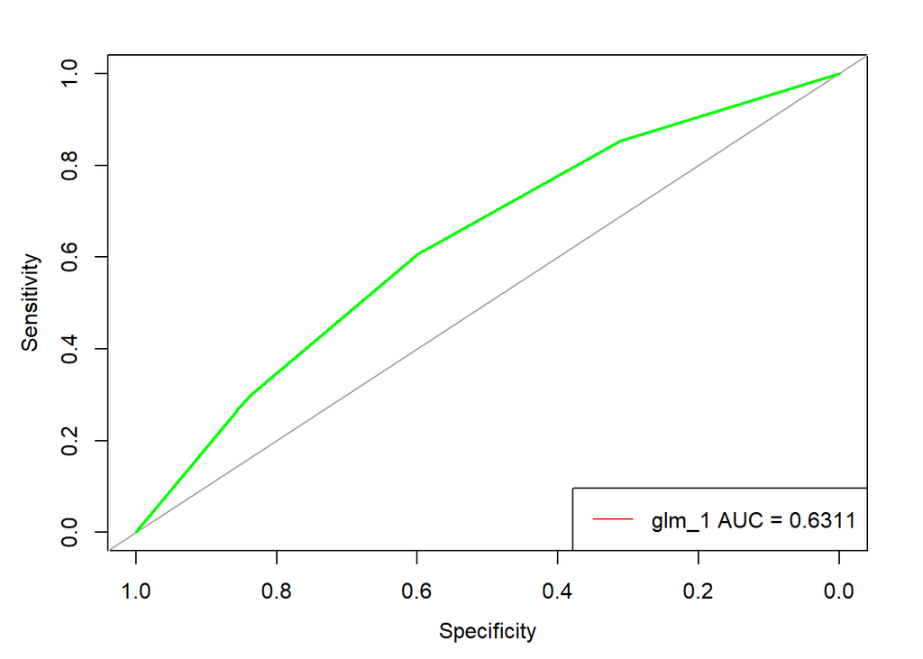

```r
pROC::plot.roc(x = roc_glm_1, legacy.axes = FALSE, xlim = c(1, 0), asp = NA, col = "green", print.auc = FALSE, print.auc.y = .4)

legend(x = "bottomright", legend=c("glm_1 AUC = 0.6311"), col = c("red"), lty = 1, cex = 1.0)
```

We see that the curve lies over the diagonal but it does not have a strong tendency to touch the upper left corner. A more complex model may perform better but would involve a larger amount of predictors

3/ Generalized Linear Model

#Check for variables left for modeling

```r
full_vars <- colnames(train_down)

full_vars
```

```
##  [1] "loan_amnt"            "funded_amnt"          "funded_amnt_inv"
##  [4] "loan_status"          "int_rate"             "grade"
##  [7] "emp_length"           "home_ownership"       "annual_inc"
## [10] "term"                 "purpose"              "total_acc"
## [13] "last_fico_range_high" "last_fico_range_low"  "default"
```

#Remove more variable

```r
model_vars <- c("term", "grade", "emp_length", "annual_inc", "purpose", "default")

ignored_vars <- dplyr::setdiff(full_vars, model_vars)

ignored_vars
```

```
## [1] "loan_amnt"            "funded_amnt"          "funded_amnt_inv"
## [4] "loan_status"          "int_rate"             "home_ownership"
## [7] "total_acc"            "last_fico_range_high" "last_fico_range_low"
```

#Control data

```r
ctrl <- trainControl(method = "repeatedcv", number = 10, repeats = 5, classProbs = TRUE, summaryFunction = twoClassSummary, savePredictions = TRUE, verboseIter = FALSE)
```

#Finishing train Dataset and creating model_glm_2

```r
model_glm_2 <- train_down %>% select(model_vars) %>% mutate(default = as.factor(ifelse(default == TRUE, "yes", "no"))) %>% filter(complete.cases(.)) %>%
train(default ~ ., data = ., method = "glm", family = "binomial", metric = "ROC", trControl = ctrl)
```

```
## Note: Using an external vector in selections is ambiguous.
## i Use `all_of(model_vars)` instead of `model_vars` to silence this message.
## i See <https://tidyselect.r-lib.org/reference/faq-external-vector.html>.
```

```r
model_glm_2
```

```
## Generalized Linear Model
##
## 36976 samples
##     5 predictor
##     2 classes: 'no', 'yes'
##
## No pre-processing
## Resampling: Cross-Validated (10 fold, repeated 5 times)
## Summary of sample sizes: 33279, 33278, 33278, 33279, 33278, 33278, ...
## Resampling results:
##
##   ROC        Sens       Spec
##   0.6329436  0.5684228  0.6292511
```

#Summary of Model_glm_2

```r
summary(model_glm_2)
```

```
##
## Call:
## NULL
##
## Deviance Residuals:
##      Min        1Q    Median        3Q       Max
## -1.57340  -1.13704   0.03486   1.08209   1.68235
##
## Coefficients:
##                             Estimate Std. Error z value Pr(>|z|)
## (Intercept)               -8.592e-01  1.267e-01  -6.782 1.18e-11 ***
## termX.60.months            2.705e-02  2.348e-02   1.152 0.249333
## gradeB                     6.236e-01  3.143e-02  19.841  < 2e-16 ***
## gradeC                     1.036e+00  3.185e-02  32.529  < 2e-16 ***
## gradeD                     1.346e+00  3.530e-02  38.127  < 2e-16 ***
## gradeE                     1.180e+00  7.500e-02  15.728  < 2e-16 ***
## gradeF                     1.400e+00  2.032e-01   6.887 5.70e-12 ***
## gradeG                     1.212e+00  4.051e-01   2.992 0.002767 **
## emp_lengthX..1.year       -5.469e-02  4.618e-02  -1.184 0.236320
## emp_lengthX1.year         -1.837e-01  5.395e-02  -3.404 0.000663 ***
## emp_lengthX10..years      -2.300e-01  4.023e-02  -5.716 1.09e-08 ***
## emp_lengthX2.years        -1.151e-01  4.996e-02  -2.305 0.021176 *
## emp_lengthX3.years        -1.382e-01  5.159e-02  -2.679 0.007389 **
## emp_lengthX4.years        -2.040e-01  5.643e-02  -3.615 0.000301 ***
## emp_lengthX5.years        -7.167e-02  5.512e-02  -1.300 0.193506
## emp_lengthX6.years        -1.995e-01  6.226e-02  -3.205 0.001353 **
## emp_lengthX7.years        -2.994e-01  6.744e-02  -4.439 9.03e-06 ***
## emp_lengthX8.years        -2.437e-01  7.122e-02  -3.421 0.000623 ***
## emp_lengthX9.years        -1.916e-01  7.856e-02  -2.439 0.014728 *
## annual_inc                 5.440e-11  9.770e-08   0.001 0.999556
## purposecredit_card         2.511e-01  1.222e-01   2.055 0.039848 *
## purposedebt_consolidation  2.814e-01  1.211e-01   2.323 0.020157 *
## purposehome_improvement    1.566e-01  1.282e-01   1.221 0.221936
## purposehouse               3.439e-01  1.636e-01   2.102 0.035567 *
## purposemajor_purchase      2.817e-02  1.449e-01   0.194 0.845802
## purposemedical             2.171e-02  1.538e-01   0.141 0.887782
## purposemoving              1.519e-01  1.831e-01   0.830 0.406795
## purposeother               9.755e-02  1.283e-01   0.760 0.447178
## purposerenewable_energy    3.943e-01  4.837e-01   0.815 0.414900
## purposesmall_business      4.364e-01  1.634e-01   2.671 0.007559 **
## purposevacation           -2.074e-02  1.773e-01  -0.117 0.906910
## ---
## Signif. codes:  0 '***' 0.001 '**' 0.01 '*' 0.05 '.' 0.1 ' ' 1
##
## (Dispersion parameter for binomial family taken to be 1)
##
##     Null deviance: 51260  on 36975  degrees of freedom
## Residual deviance: 49128  on 36945  degrees of freedom
## AIC: 49190
##
## Number of Fisher Scoring iterations: 4
```

#Predictor of model_glm_2

```r
predictors(model_glm_2)
```

```
##  [1] "termX.60.months"           "gradeB"
##  [3] "gradeC"                    "gradeD"
##  [5] "gradeE"                    "gradeF"
##  [7] "gradeG"                    "emp_lengthX..1.year"
##  [9] "emp_lengthX1.year"         "emp_lengthX10..years"
## [11] "emp_lengthX2.years"        "emp_lengthX3.years"
## [13] "emp_lengthX4.years"        "emp_lengthX5.years"
## [15] "emp_lengthX6.years"        "emp_lengthX7.years"
## [17] "emp_lengthX8.years"        "emp_lengthX9.years"
## [19] "annual_inc"                "purposecredit_card"
## [21] "purposedebt_consolidation" "purposehome_improvement"
## [23] "purposehouse"              "purposemajor_purchase"
## [25] "purposemedical"            "purposemoving"
## [27] "purposeother"              "purposerenewable_energy"
## [29] "purposesmall_business"     "purposevacation"
```

#Check importance variables

```r
varImp(model_glm_2)
```

```
## glm variable importance
##
##   only 20 most important variables shown (out of 30)
##
##                           Overall
## gradeD                    100.000
## gradeC                     85.316
## gradeB                     52.038
## gradeE                     41.250
## gradeF                     18.062
## emp_lengthX10..years       14.991
## emp_lengthX7.years         11.642
## emp_lengthX4.years          9.480
## emp_lengthX8.years          8.972
## emp_lengthX1.year           8.927
## emp_lengthX6.years          8.404
## gradeG                      7.847
## emp_lengthX3.years          7.024
## purposesmall_business       7.005
## emp_lengthX9.years          6.396
## purposedebt_consolidation   6.092
## emp_lengthX2.years          6.044
## purposehouse                5.511
## purposecredit_card          5.389
## emp_lengthX5.years          3.409
```

#Plot Important Variables

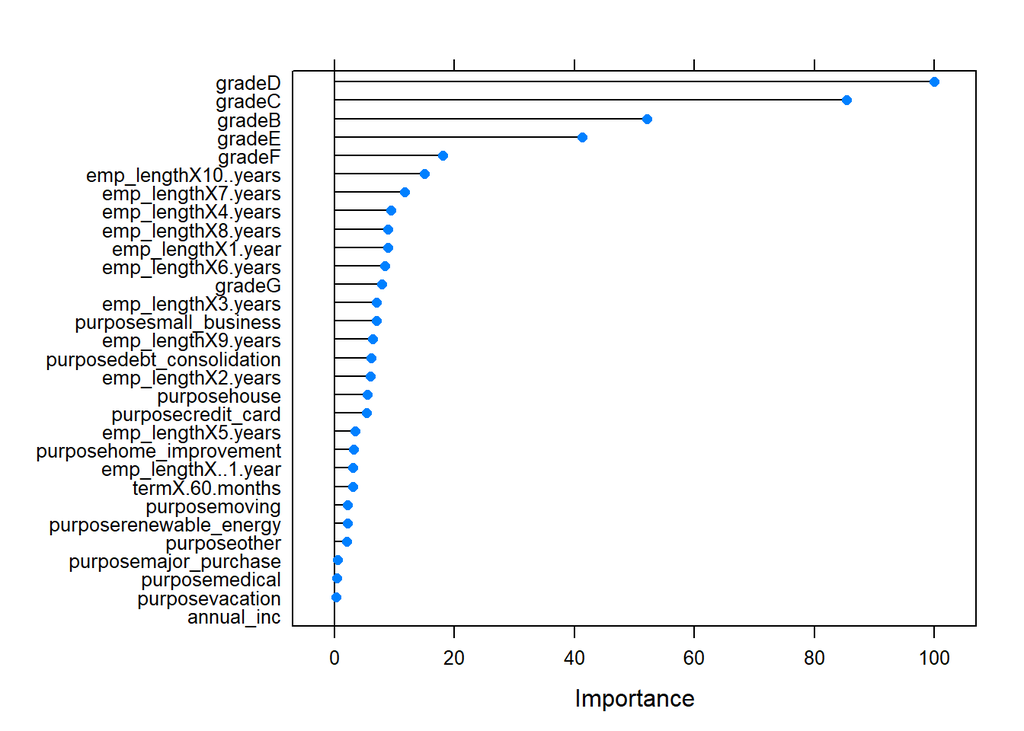

```r
plot(varImp(model_glm_2))
```

#Prediction model_glm_2

```r
model_glm_2_pred <- predict(model_glm_2, newdata = test, type = "prob")

head(model_glm_2_pred, 3)
```

```
##          no       yes
## 1 0.4818120 0.5181880
## 2 0.7176025 0.2823975
## 3 0.5296718 0.4703282
```

#Check performance of new model

```r
caret::confusionMatrix( data = as.factor(ifelse(model_glm_2_pred[, "yes"] > 0.5, "yes", "no")), reference = as.factor(ifelse(test[complete.cases(test[, model_vars]), "default"] == TRUE, "yes", "no")))
```

```
## Confusion Matrix and Statistics
##
##           Reference
## Prediction     no    yes
##        no  113088   1684
##        yes  84389   2937
##
##                Accuracy : 0.5741
##                  95% CI : (0.5719, 0.5763)
##     No Information Rate : 0.9771
##     P-Value [Acc > NIR] : 1
##
##                   Kappa : 0.0214
##
##  Mcnemar's Test P-Value : <2e-16
##
##             Sensitivity : 0.57266
##             Specificity : 0.63558
##          Pos Pred Value : 0.98533
##          Neg Pred Value : 0.03363
##              Prevalence : 0.97713
##          Detection Rate : 0.55957
##    Detection Prevalence : 0.56790
##       Balanced Accuracy : 0.60412
##
##        'Positive' Class : no
##
```

#Build ROC for glme_2

```r
temp <- as.factor(ifelse(test[complete.cases(test[, model_vars]), "default"] == TRUE, "yes", "no"))

roc_glm_2 <- pROC::roc(response = temp, predictor = model_glm_2_pred[, "yes"])
roc_glm_2
```

```
##
## Call:
## roc.default(response = temp, predictor = model_glm_2_pred[, "yes"])
##
## Data: model_glm_2_pred[, "yes"] in 197477 controls (temp no) < 4621 cases (temp yes).
## Area under the curve: 0.6387
```

#Plot ROC roc_glm_1 and roc_glm_2

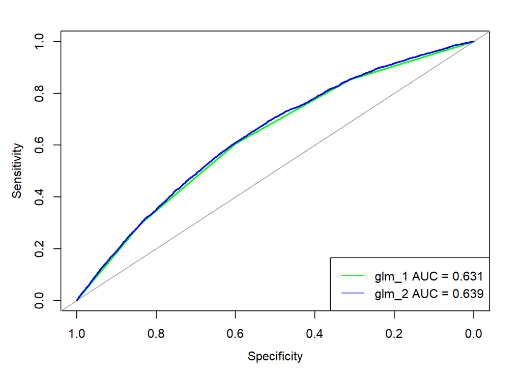

```r
pROC::plot.roc(x = roc_glm_1, legacy.axes = FALSE, xlim = c(1, 0), asp = NA,
               col = "green")

pROC::plot.roc(x = roc_glm_2, legacy.axes = FALSE, xlim = c(1, 0), asp = NA,
               add = TRUE, col = "blue")

legend(x = "bottomright", legend=c("glm_1 AUC = 0.631", "glm_2 AUC = 0.639"),
       col = c("green", "blue"), lty = 1, cex = 1.0)
```

4/ Trees Model

#Define control and train functions

```r
ctrl <- trainControl(method = "repeatedcv", number = 10, repeats = 5, classProbs = TRUE, summaryFunction = twoClassSummary, verboseIter = FALSE, allowParallel = TRUE)

library(rpart)

model_rpart <- train_down %>% select(model_vars) %>% mutate(default = as.factor(ifelse(default == TRUE, "yes", "no"))) %>% filter(complete.cases(.)) %>% train(default ~ ., data = ., method = 'rpart', metric = "ROC", preProc = c("center", "scale"), trControl = ctrl)

model_rpart
```

```
## CART
##
## 36976 samples
##     5 predictor
##     2 classes: 'no', 'yes'
##
## Pre-processing: centered (30), scaled (30)
## Resampling: Cross-Validated (10 fold, repeated 5 times)
## Summary of sample sizes: 33279, 33278, 33279, 33278, 33278, 33278, ...
## Resampling results across tuning parameters:
##
##   cp          ROC        Sens       Spec
##   0.00473280  0.6125602  0.6119105  0.5796511
##   0.07642795  0.5738026  0.7568160  0.3822176
##   0.11277585  0.5240090  0.8893192  0.1586987
##
## ROC was used to select the optimal model using the largest value.
## The final value used for the model was cp = 0.0047328.
```

#Plot Model_rpart

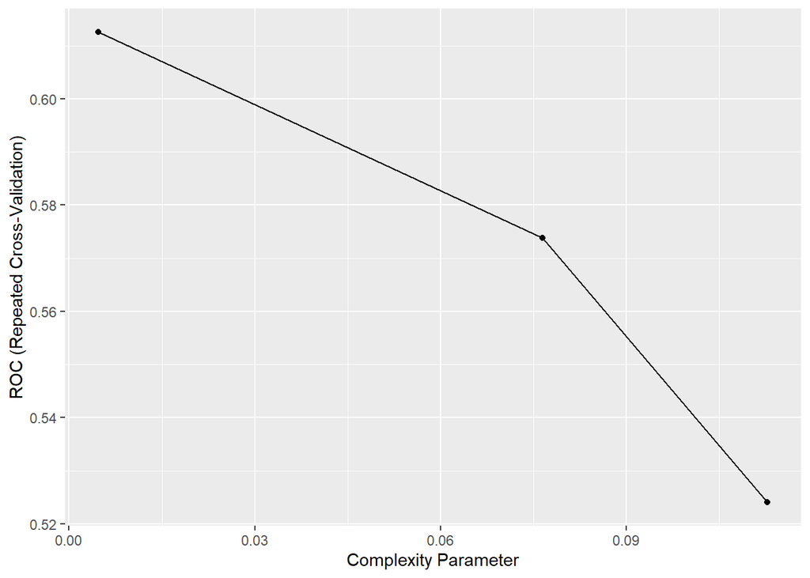

```r
ggplot(model_rpart)
```

#The final tree

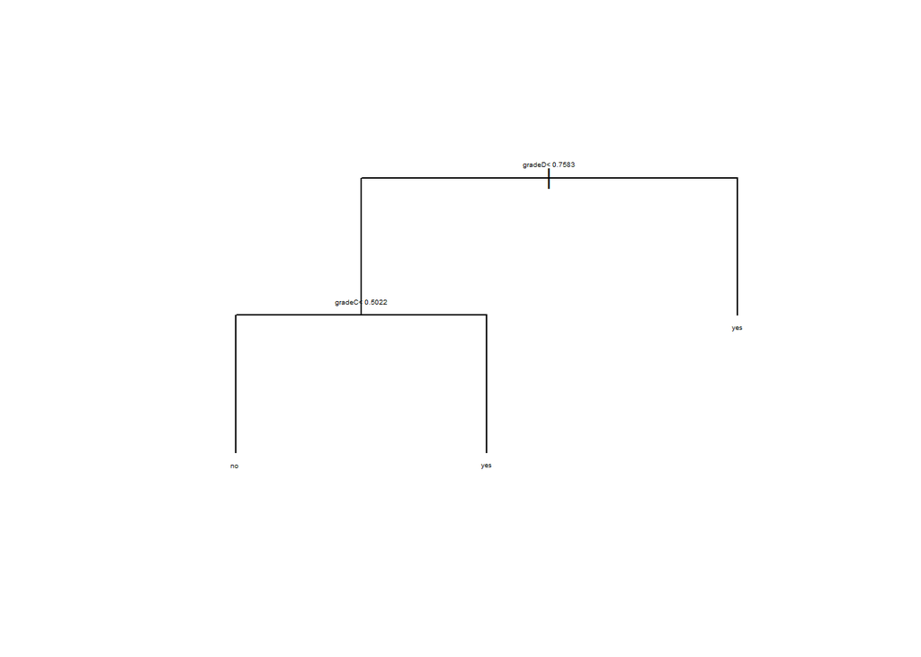

```r
plot(model_rpart$finalModel, uniform = TRUE, margin = 0.2)
graphics::text(model_rpart$finalModel, cex = 0.3)
```

#Using Random Search

```r
ctrl <- trainControl(method = "repeatedcv", number = 10, repeats = 5, classProbs = TRUE, summaryFunction = twoClassSummary, verboseIter = FALSE, allowParallel = TRUE, search = "random")

model_rpart <- train_down %>% select(model_vars) %>% mutate(default = as.factor(ifelse(default == TRUE, "yes", "no"))) %>% filter(complete.cases(.)) %>% train(default ~ ., data = ., method = 'rpart', metric = "ROC", preProc = c("center", "scale"), trControl = ctrl)

model_rpart
```

```
## CART
##
## 36976 samples
##     5 predictor
##     2 classes: 'no', 'yes'
##
## Pre-processing: centered (30), scaled (30)
## Resampling: Cross-Validated (10 fold, repeated 5 times)
## Summary of sample sizes: 33279, 33279, 33279, 33278, 33278, 33278, ...
## Resampling results across tuning parameters:
##
##   cp            ROC        Sens       Spec
##   9.014856e-06  0.5767794  0.5536026  0.5507783
##   1.081783e-04  0.6027719  0.5590327  0.6079076
##   1.217006e-04  0.6083938  0.5530508  0.6192559
##
## ROC was used to select the optimal model using the largest value.
## The final value used for the model was cp = 0.0001217006.
```

#Predict for model_rpart

```r
model_rpart_pred <- predict(model_rpart, newdata = test %>% select(model_vars) %>% mutate(default = as.factor(ifelse(default == TRUE, "yes", "no"))) %>% filter(complete.cases(.)), type = "prob")

caret::confusionMatrix( data = as.factor(ifelse(model_rpart_pred[, "yes"] > 0.5, "yes", "no")), reference = as.factor(ifelse(test[complete.cases(test[,model_vars]), "default"] == TRUE, "yes", "no")))
```

```
## Confusion Matrix and Statistics
##
##           Reference
## Prediction     no    yes
##        no  108440   1738
##        yes  89037   2883
##
##                Accuracy : 0.5508
##                  95% CI : (0.5487, 0.553)
##     No Information Rate : 0.9771
##     P-Value [Acc > NIR] : 1
##
##                   Kappa : 0.0169
##
##  Mcnemar's Test P-Value : <2e-16
##
##             Sensitivity : 0.54913
##             Specificity : 0.62389
##          Pos Pred Value : 0.98423
##          Neg Pred Value : 0.03136
##              Prevalence : 0.97713
##          Detection Rate : 0.53657
##    Detection Prevalence : 0.54517
##       Balanced Accuracy : 0.58651
##
##        'Positive' Class : no
##
```

#Compute ROC for roc_rpart

```r
roc_rpart <-
  pROC::roc(response = temp,
            predictor = model_rpart_pred[, "yes"])
roc_rpart
```

```
##
## Call:
## roc.default(response = temp, predictor = model_rpart_pred[, "yes"])
##
## Data: model_rpart_pred[, "yes"] in 197477 controls (temp no) < 4621 cases (temp yes).
## Area under the curve: 0.6079
```

The ROCAUC is 60% which is little lower comparing with cross-validated training set.